# TidyTuesday - Passwords

John Joyce

4/5/2021

# Intro

This document is a [TidyTuesday](https://github.com/rfordatascience/tidytuesday) submission for the [passwords dataset](https://github.com/rfordatascience/tidytuesday/tree/master/data/2020/2020-01-14) from January 2020. You can learn more about the original source from [Information is Beautiful](https://twitter.com/infobeautiful/status/1216765612439019521?s=20).

The data is a list of the top 500 most popular passwords, according to information scraped from multiple data breaches. The passwords are ranked according to their frequency, and the authors provide a few metrics for each password. (We’ll explore those metrics in the questions below.)

```r
library(tidyverse) # ggplot, lubridate, maggitr pipes, etc.
library(data.table) # main data manipulation tool
library(ggiraph) # interactive ggplots
library(waffle) # helper for 'waffle' plot (square pie chart)
library(hrbrthemes) # supporting themes for waffle plot
library(kableExtra) # fancy html tables
library(gganimate) # entropy animation in ggplot2

# read CSV from GitHub into data.table
dt <- fread('https://raw.githubusercontent.com/rfordatascience/tidytuesday/master/data/2020/2020-01-14/passwords.csv')

# show a preview in the markdown files
dt %>%
  kbl %>%
  kable_paper %>%
  scroll_box(width = "100%", height = "500px")
```

| rank | password | category | value | time_unit | offline_crack_sec | rank_alt | strength | font_size |
| --- | --- | --- | --- | --- | --- | --- | --- | --- |
| 1 | password | password-related | 6.91 | years | 2.170e+00 | 1 | 8 | 11 |
| 2 | 123456 | simple-alphanumeric | 18.52 | minutes | 1.110e-05 | 2 | 4 | 8 |
| 3 | 12345678 | simple-alphanumeric | 1.29 | days | 1.110e-03 | 3 | 4 | 8 |
| 4 | 1234 | simple-alphanumeric | 11.11 | seconds | 1.000e-07 | 4 | 4 | 8 |
| 5 | qwerty | simple-alphanumeric | 3.72 | days | 3.210e-03 | 5 | 8 | 11 |
| 6 | 12345 | simple-alphanumeric | 1.85 | minutes | 1.100e-06 | 6 | 4 | 8 |
| 7 | dragon | animal | 3.72 | days | 3.210e-03 | 7 | 8 | 11 |
| 8 | baseball | sport | 6.91 | years | 2.170e+00 | 8 | 4 | 8 |
| 9 | football | sport | 6.91 | years | 2.170e+00 | 9 | 7 | 11 |
| 10 | letmein | password-related | 3.19 | months | 8.350e-02 | 10 | 8 | 11 |
| 11 | monkey | animal | 3.72 | days | 3.210e-03 | 11 | 8 | 11 |
| 12 | 696969 | simple-alphanumeric | 18.52 | minutes | 1.110e-05 | 12 | 1 | 4 |
| 13 | abc123 | simple-alphanumeric | 3.70 | weeks | 2.240e-02 | 13 | 32 | 23 |
| 14 | mustang | cool-macho | 3.19 | months | 8.350e-02 | 14 | 9 | 12 |
| 15 | michael | name | 3.19 | months | 8.350e-02 | 15 | 9 | 12 |
| 16 | shadow | cool-macho | 3.72 | days | 3.210e-03 | 16 | 8 | 11 |
| 17 | master | cool-macho | 3.72 | days | 3.210e-03 | 17 | 8 | 11 |
| 18 | jennifer | name | 6.91 | years | 2.170e+00 | 18 | 9 | 12 |
| 19 | 111111 | simple-alphanumeric | 18.52 | minutes | 1.110e-05 | 19 | 0 | 0 |
| 20 | 2000 | simple-alphanumeric | 11.11 | seconds | 1.000e-07 | 20 | 0 | 0 |
| 21 | jordan | name | 3.72 | days | 3.210e-03 | 21 | 8 | 11 |
| 22 | superman | name | 6.91 | years | 2.170e+00 | 22 | 10 | 13 |
| 23 | harley | cool-macho | 3.72 | days | 3.210e-03 | 23 | 8 | 11 |
| 24 | 1234567 | simple-alphanumeric | 3.09 | hours | 1.110e-04 | 24 | 4 | 8 |
| 25 | hunter | cool-macho | 3.72 | days | 3.210e-03 | 25 | 8 | 11 |
| 26 | trustno1 | simple-alphanumeric | 92.27 | years | 2.902e+01 | 26 | 25 | 20 |
| 27 | ranger | cool-macho | 3.72 | days | 3.210e-03 | 27 | 7 | 11 |
| 28 | buster | cool-macho | 3.72 | days | 3.210e-03 | 28 | 8 | 11 |
| 29 | thomas | name | 3.72 | days | 3.210e-03 | 29 | 8 | 11 |
| 30 | tigger | name | 3.72 | days | 3.210e-03 | 30 | 6 | 10 |

[output cut: 477 more lines]

```r
# the last 7 rows are completely NAs - this must be a mistake in the CSV
# drop them
dt <- na.omit(dt)
```

# Question 1: How strong are these passwords?

Let’s start with a little exploration. The data authors include a **strength** rating as one of the columns, which runs from 0 - 48. A higher number is better. So how do these passwords stack up?

The distribution of the histogram shows that *most of them are terrible*. In fact, it’s rare for one of these common passwords to be decent. Most of them have a strength rating below 10!

```r
# histogram of password strength
strength_hist <-
  ggplot(dt, aes(x = strength)) +
  geom_histogram_interactive(aes(tooltip = paste0(round(..density.., 3) * 100, '%', ' of passwords'), data_id = strength), fill = 'lavenderblush4') +
  theme_light() +
  labs(x = 'Strength', y = 'Count', title = 'Password Strength Distribution')

girafe(ggobj = strength_hist)
```

[interactive chart not shown]

# Question 2: Are some categories better than others?

The authors assigned categories which describe the general theme of the passwords (sports, names, rude language, etc.). Are some of these categories stronger than others?

My take on the plot below: no, they’re all terrible. We may notice that **nerdy-pop** and **simple-alphanumeric** have a few decent passwords (notably they all include letters and numbers), but these are outliers. The averages for all groups are quite low and basically in the same range, except for **food** and **simple-alphanumeric** which stick out as slightly worse.

```r
# boxplot of strength within categories
strength_by_cat <-
    ggplot(dt, aes(x = category, y = strength)) +
    geom_boxplot_interactive(aes(fill = category), outlier.shape = NA) +
    geom_jitter_interactive(aes(tooltip = password, data_id = category, color = category), width = 0.55, height = 1, alpha = 0.25) + # use this layer for points with tooltips
    labs(x = '', y = 'Strength', title = 'Password Strength by Category') +
    theme_light() +
    theme(axis.text.x = element_text(angle = 90, vjust = 0.5, hjust=1),
          legend.position = 'none')

# show the boxplot
girafe(ggobj = strength_by_cat,
       options = list(opts_hover_inv(css = "opacity:0.1;")))
```

[interactive chart not shown]

# Question 3: How do these passwords stand up to online attacks?

It’s clear that many of these passwords are simply bad. The data authors provide us with an estimate of how long each password would take to crack in an *online attack* (e.g. an attacker tries to guess every combination of characters at the login page).

This estimate is provided in two columns, **value** and **time_unit**. The estimates come in many different formats (2.1 hours, 3.3 weeks, 5.4 months, 6.7 years, etc.).

To answer this question in a few steps:  
1. standardize all the estimates to a single time unit: seconds  
2. create a new column, which flags all passwords that could survive > 6 months  
3. visualize the results with some help from the [waffle package](https://github.com/hrbrmstr/waffle)

How many of these common passwords could last 6 months against a motivated attacker? Well, not many…

```r
##### STANDARDIZE ONLINE CRACK TIME ESTIMATES #####


# this function converts any time format in the data to seconds
time_converter_secs <- function (value, time_unit){

  duration <- as.numeric(lubridate::duration(value, unit = time_unit))

  return(duration)

}


# create new column with standardized online crack times in SECONDS
dt[, online_crack_sec := mapply(time_converter_secs, value, time_unit)]


##### CREATE A NEW COLUMN TO INDICATE WHICH PASSWORDS SURVIVE 6 MONTHS #####


# store 6 months in seconds in a variable for comparison
six_months <- as.integer(lubridate::duration(num = 6, units = 'months'))

# add a new columns with factor levels - would this password survive a 6 mo. online attack?
dt[, survive_six_months := ifelse(online_crack_sec > six_months, 'Survived', 'Hacked')]


##### VISUALIZE RESULTS #####


# create a named vector to input to waffle() to create the base ggplot
dt_grouped <- dt[, .(count = .N), by = survive_six_months] # getting counts for groups
waffle_vector <- dt_grouped$count # put counts into vector
names(waffle_vector) <- c('Survived', 'Hacked') # add names to avoid confusion

# create ordered table for the interactive layer which the viewer sees
ordered_data <- dt[order(-survive_six_months)]

# create waffle chart
waffle_chart <-
  waffle(waffle_vector) + # base layer sets the waffle chart grid
  geom_point_interactive(aes(color = ordered_data$survive_six_months, # interactive layer for tooltips
                             tooltip = ordered_data$password),
                         shape = 15) +
  scale_color_manual_interactive(values = c('orangered2', 'steelblue'), aesthetics = 'color') +
  labs(title = "Password Strength VS Online Attack",
       subtitle = 'How many of these passwords would survive a 6-month online attack?') +
  guides(color=guide_legend(" "), fill = FALSE) +
  theme(legend.position = 'top')


# show chart
girafe(ggobj = waffle_chart)
```

[interactive chart not shown]

# Question 4: What is entropy?

The dataset doesn’t say anything about entropy directly, but it’s important to understand what’s going on here. When it comes to passwords, entropy is the level of uncertainty around the specific combination of characters that make up your password. Higher entropy (higher uncertainty about what the combination might be) is associated with stronger passwords.

There are two elements that go into entropy:  
1. the length of the password  
2. the number of potential characters at every position

That’s why many password policies say that you must have a mix of letters, numbers, and symbols, as well as a minimum length. It’s about increasing entropy. The animation below demonstrates the relationship of length, complexity, and entropy. (This is an entirely fictional password which no one should ever use!)

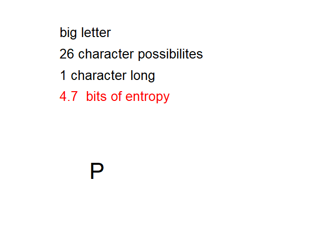

```r
# this DF has 8 rows. each one is a different frame in an animation about entropy
df <- data.frame(letters = c('P',
                             'Pa',
                             'Pa5',
                             'Pa5$',
                             'Pa5$w',
                             'Pa5$wo',
                             'Pa5$wor',
                             'Pa5$word'),
                 comment = c('big letter',
                             'big + small letters',
                             'big + small letters + digits',
                             'big + small letters + digits + symbols',
                             'big + small letters + digits + symbols',
                             'big + small letters + digits + symbols',
                             'big + small letters + digits + symbols',
                             'big + small letters + digits + symbols'),
                 comment2 = c('26 character possibilites',
                              '52 character possibilities',
                              '62 character possibilities',
                              '77 character possibilities',
                              '77 character possibilities',
                              '77 character possibilities',
                              '77 character possibilities',
                              '77 character possibilities'),
                 comment3 = c('1 character long',
                              '2 characters long',
                              '3 characters long',
                              '4 characters long',
                              '5 characters long',
                              '6 characters long',
                              '7 characters long',
                              '8 characters long'),
                 comment4 = c(paste(round(log2(26^1),3), ' bits of entropy'),
                              paste(round(log2(52^2),3), ' bits of entropy'),
                              paste(round(log2(62^3),3), ' bits of entropy'),
                              paste(round(log2(77^4),3), ' bits of entropy'),
                              paste(round(log2(77^5),3), ' bits of entropy'),
                              paste(round(log2(77^6),3), ' bits of entropy'),
                              paste(round(log2(77^7),3), ' bits of entropy'),
                              paste(round(log2(77^8),3), ' bits of entropy')),
                 x = rep(0.75,8),
                 y = rep(0.75,8),
                 frames = seq(1,8))

# save the animation to an object
animation <-
ggplot(df, aes(x = x, y = y)) +
  geom_text(aes(label = letters), size = 12, hjust = 0) +
  geom_text(aes(x - 0.1, y + 0.65, label = comment), size = 7, hjust = 0) +
  geom_text(aes(x - 0.1, y + 0.55, label = comment2), size = 7, hjust = 0) +
  geom_text(aes(x - 0.1, y + 0.45, label = comment3), size = 7, hjust = 0) +
  geom_text(aes(x - 0.1, y + 0.35, label = comment4), size = 7, color = 'red', hjust = 0) +
  theme_void() +
  scale_x_continuous(limits = c(0.5, 1.5)) +
  scale_y_continuous(limits = c(0.5, 1.5)) +
  transition_states(frames)

animate(animation, nframes = 64)
```

# Question 5: How does entropy affect offline cracking time?

The fact is, most passwords are not cracked in isolated online attacks. When a large company suffers a data breach and the encrypted passwords get published on the internet, hackers download the whole trove and start attempting to crack the passwords offline on their own computers. They can crack passwords much faster in this setting.

To answer this question:  
1. create new columns for password length and complexity  
2. calculate entropy from these columns  
3. plot the relationship between entropy and offline crack time

You can view an explanation of the entropy calculation [here](https://generatepasswords.org/how-to-calculate-entropy/).

The plot below makes two points:  
1. The relationship between entropy and crack time is exponential! Once you achieve a certain amount of entropy (around 35 bits here), each additional bit increases your protection *a lot*.  
2. The common passwords are so bad, that none of them would last even 30 seconds in an offline attack.

```r
# function scores possible character combinations in a password
char_complexity_eval <- function(string){

  score <- 0 # base complexity

  score <- ifelse(str_detect(string, '[a-z]'), score + 26, score) # lower case letter
  score <- ifelse(str_detect(string, '[A-Z]'), score + 26, score) # upper case letters
  score <- ifelse(str_detect(string, '\\d'), score + 10, score) # digits
  score <- ifelse(str_detect(string, '\\W'), score + 15, score) # symbols
# number for symbols is a rough guess - different sites have different policies about which symbols are allowed

  return(score)
}

# create columns for character length and number of possible characters
dt[, `:=` (length_characters = nchar(password),
           possible_character_count = char_complexity_eval(password))]

# calculate entropy based on password length and theoretical complexity
dt[, bits_entropy := log2(possible_character_count^length_characters)]

# scatterplot of entropy VS offline crack time
entropy_scatter <-
ggplot(dt, aes(x = bits_entropy, y = offline_crack_sec)) +
  geom_point() +
  geom_smooth_interactive(color = 'red') +
  geom_point_interactive(aes(tooltip = paste('Bits of entropy:',
                                              round(bits_entropy, 3),
                                             '\n Time to crack offline:',
                                             offline_crack_sec,
                                             'seconds',
                                             sep = ' '))) +
  theme_light() +
  labs(x = 'Entropy (bits)',
       y = 'Seconds to Crack Offline',
       title = 'Entropy & Offline Crack Time')


# show plot
girafe(ggobj = entropy_scatter)
```

[interactive chart not shown]

# Bonus question: So, what are the worst popular passwords out there?

It’s already apparent that these popular passwords are bad. But which ones are **the most popular** and **most insecure**?

Just for fun, I looked at the **top 100** most popular passwords in the data, and picked the ten worst of the bunch by entropy. Don’t ever use these! (Or… any of the other passwords in this data.)

```r
# consider the top 100 passwords, find the worst 10 by entropy
worst_of_top100 <- dt[rank <= 100][order(bits_entropy)][1:10]

# horizontal lollipop chart of worst popular passwords
worst_plot <-
ggplot(worst_of_top100, aes(x = reorder(password, -bits_entropy), y = bits_entropy)) +
  geom_segment_interactive(aes(xend = password,
                               y = 0,
                               yend = bits_entropy,
                               tooltip = paste(round(bits_entropy, 3), ' bits')),
                           color="grey22",
                           size = 2) +
  geom_point_interactive(aes(tooltip = paste('Popularity rank: #', rank,
                                             '\n Online hack in: ', time_unit,
                                             '\n Offline hack in: nearly instant')),
                         color="orange",
                         size=5) +
  theme_light() +
  coord_flip() +
  theme_classic() +
  ylim(0,25) +
  labs(x =  '', y = 'Entropy (bits)', title = 'Really Bad, Really Popular Passwords') +
  theme(axis.text.y = element_text(face = "bold", size = 10)) # confusing: need to call this y axis after coord_flip()

# show the plot
girafe(ggobj = worst_plot)
```

[interactive chart not shown]